# Worksheet: Project

## 1. Introduction

### a. Set up

First load the packages you will use throughout the document. *Note: you can hide this step in the resulting output with the option `echo=FALSE`.*

### b. Quick description of the dataset(s)

Then call the dataset(s) you will need to join. If stored locally, make sure the datasets are saved in the same folder as your RMarkdown file (the working directory). Otherwise, R would not know where to look for the data!

Remember the following data from the GitHub page about Amazon reviews (originally obtained from https://s3.amazonaws.com/amazon-reviews-pds/readme.html):

```r
# Upload data from GitHub for Amazon Reviews of "Digital Software"
amazon <- read_tsv("https://github.com/rdpeng/stat322E_public/raw/main/data/amazon_reviews_us_Digital_Software_v1_00.tsv.gz")

## Take a look
glimpse(amazon)
```

```
## Rows: 98,438
## Columns: 15
## $ marketplace       <chr> "US", "US", "US", "US", "US", "US", "US", "US", "US"…
## $ customer_id       <dbl> 17747349, 10956619, 13132245, 35717248, 17710652, 42…
## $ review_id         <chr> "R2EI7QLPK4LF7U", "R1W5OMFK1Q3I3O", "RPZWSYWRP92GI",…
## $ product_id        <chr> "B00U7LCE6A", "B00HRJMOM4", "B00P31G9PQ", "B00FGDEPD…
## $ product_parent    <dbl> 106182406, 162269768, 831433899, 991059534, 57490455…
## $ product_title     <chr> "CCleaner Free [Download]", "ResumeMaker Professiona…
## $ product_category  <chr> "Digital_Software", "Digital_Software", "Digital_Sof…
## $ star_rating       <dbl> 4, 3, 1, 5, 4, 5, 1, 1, 1, 5, 5, 1, 5, 1, 3, 1, 2, 5…
## $ helpful_votes     <dbl> 0, 0, 1, 0, 1, 4, 1, 0, 0, 0, 0, 0, 0, 0, 2, 2, 0, 0…
## $ total_votes       <dbl> 0, 0, 2, 0, 2, 4, 1, 0, 0, 0, 0, 2, 0, 1, 3, 2, 0, 0…
## $ vine              <chr> "N", "N", "N", "N", "N", "N", "N", "N", "N", "N", "N…
## $ verified_purchase <chr> "Y", "Y", "Y", "Y", "Y", "N", "N", "Y", "Y", "Y", "Y…
## $ review_headline   <chr> "Four Stars", "Three Stars", "One Star", "Works as E…
## $ review_body       <chr> "So far so good", "Needs a little more work.....", "…
## $ review_date       <date> 2015-08-31, 2015-08-31, 2015-08-31, 2015-08-31, 201…
```

There are 98,438 observations and 15 variables. Each row corresponds to a unique review id:

```r
# Create a dataset we can use to answer our research question
amazon %>%
  summarize(n_reviews = n_distinct(review_id))
```

```
## # A tibble: 1 × 1
##   n_reviews
##       <int>
## 1     98438
```

### c. Define a research question

One thing we might want to explore is how the comments left by the reviewers relate to the star rating given. For example, we can look at the sentiment of the words in each comment and calculate a sentiment score for each review. We might expect to find that the higher the rating, the more positive the sentiment.

The information we would like to investigate is not directly shown in our dataset though. We need some wrangling!

## 2,3,4. Make our data analyzable

For your project, you’ll do some tidying and joining. Here is a giant piece of code that wrangles our data and results in a dataframe containing: the number of words per review, their average “sentiment”, and the star rating (it’s ok to break a code like this into smaller pieces with temporary datasets).

```r
# Create a dataset we can use to answer our research question
amazon %>%
  select(review_id, review_body) %>% # only keep information about the review comments
  unnest_tokens(word, review_body) %>% # split each review as words
  left_join(get_sentiments("afinn"), by = "word") %>% # add a sentiment if available
  group_by(review_id) %>% # now per review, find...
  summarize(avg_sentiment = mean(value, na.rm = TRUE), #... the average sentiment
            n_words = n()) %>% #... the number of words
  mutate(avg_sentiment = ifelse(is.na(avg_sentiment), # if missing sentiment...
                        0, avg_sentiment)) %>% # average sentiment is 0
  inner_join(amazon %>% select(review_id, star_rating), # add information about star rating
             by = "review_id") -> analyzable_amazon
```

## 5. Visualize and analyze our data

Describe some aspects of the reviews: distribution of the average sentiment and number of words.

```r
# Summary statistics about the average sentiment
summary(analyzable_amazon$avg_sentiment)
```

```
##    Min. 1st Qu.  Median    Mean 3rd Qu.    Max.
## -5.0000  0.0000  0.8750  0.8444  2.0000  5.0000
```

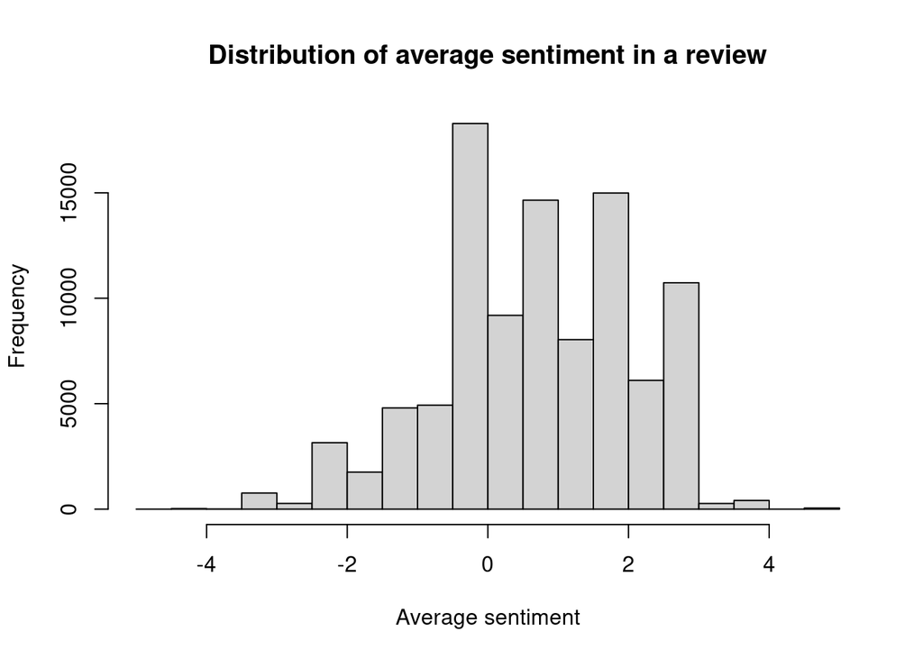

```r
hist(analyzable_amazon$avg_sentiment,
     xlab = "Average sentiment",
     main = "Distribution of average sentiment in a review")
```

```r
# Summary statistics about the number of words
summary(analyzable_amazon$n_words)
```

```
##    Min. 1st Qu.  Median    Mean 3rd Qu.    Max.
##    1.00   20.00   36.00   68.56   79.00 5426.00
```

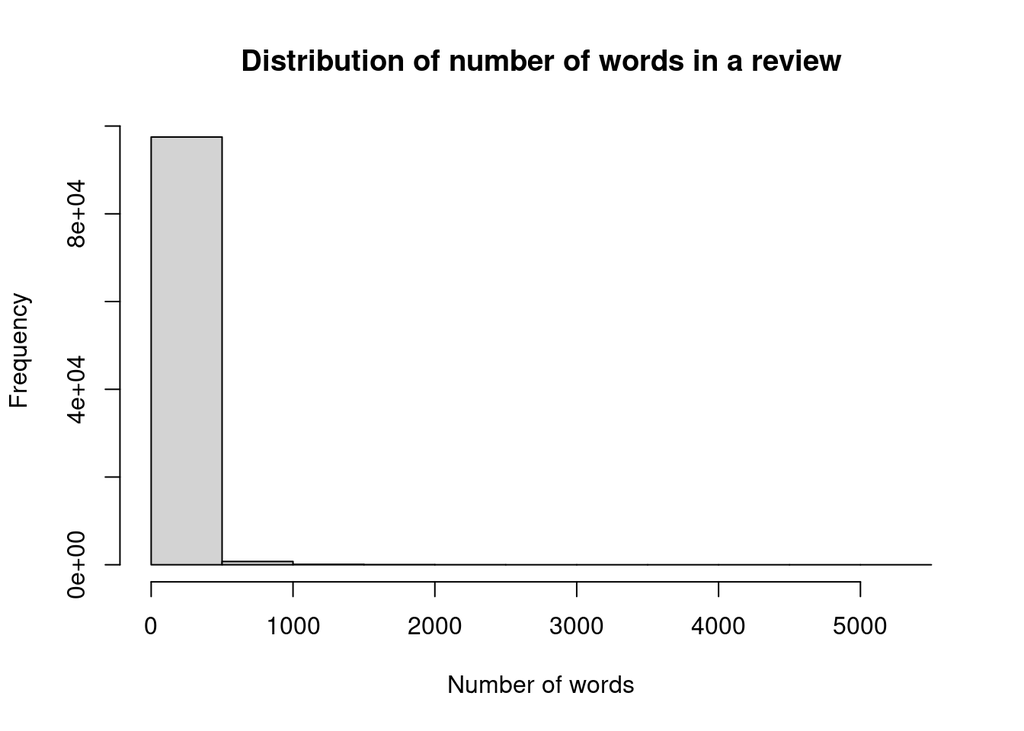

```r
hist(analyzable_amazon$n_words,
     xlab = "Number of words",
     main = "Distribution of number of words in a review")
```

Think about what the statistics reveal about the distributions. Make sure to report appropriate units.

Then move into looking for patterns:

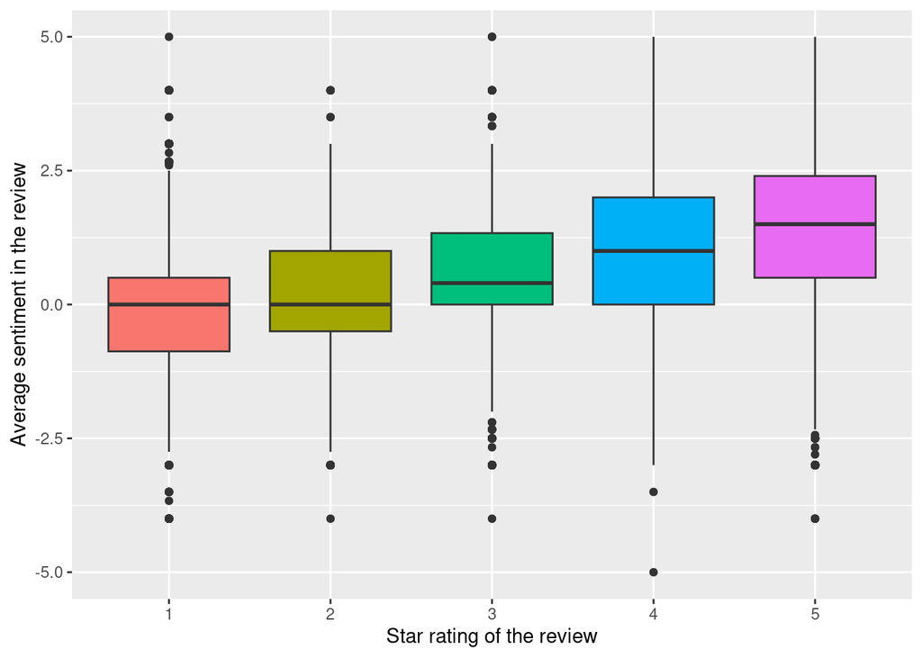

```r
# Relationship between star rating and average sentiment
ggplot(data = analyzable_amazon, aes(x = as.factor(star_rating), y = avg_sentiment)) +
  geom_boxplot(aes(fill = as.factor(star_rating)), show.legend = FALSE) +
  labs(x = "Star rating of the review", y = "Average sentiment in the review")
```

Think about what this graph shows compared to what we expected. Anything surprising?

What about the comments with negative sentiments and high ratings? Or low ratings and positive sentiments? We could investigate our data a little more to understand what is going on.

```r
analyzable_amazon %>%
  inner_join(amazon %>% select(review_id, review_body), # add information about full review comments
             by = "review_id") %>%
  filter(star_rating == 5, avg_sentiment < -3)
```

```
## # A tibble: 4 × 5
##   review_id      avg_sentiment n_words star_rating review_body
##   <chr>                  <dbl>   <int>       <dbl> <chr>
## 1 R18Q2BCG1H9FRJ            -4      24           5 Yup you guessed it, the pric…
## 2 R23ZS594H2KKYL            -4       6           5 It is a fuking must have
## 3 R3AU7FHQ6FM03K            -4       4           5 Ass you know it
## 4 RMUJSCU75826E             -4      14           5 Finally I can make my wife d…
```

## 6. Discussion

While we observed that overall a higher rating seems to be associated with a more positive sentiment, we should be careful about our interpretation as some words might have been misinterpreted (note: if you check the words with star rating of 1, a lot of the comments mention “not good” which is misinterpreted as “good” when we split the comments by word). Suggest what could be done better in the future to investigate this type of data.

## 7. Formatting

Remember to knit your file and produce a pdf with multiple pages to upload on Gradescope. It is ok to not follow the structure of the project in order (you might need to join before you tidy, or wrangle before you join, etc.). Just make sure to identify the page in which you apply the tidying functions, joining functions, wrangling functions, …

*Acknowledgements: thanks to Dr. Peng for providing this dataset!*